# Reproducible Research - Project 1

ThierryFauret

6 mai 2017

## Loading and preprocessing the data

```r
library(dplyr)
library(lubridate)
library(ggplot2)
activity<-read.csv("activity.csv",sep=",")
activity<-mutate(activity,steps=as.numeric(steps))

ok<-complete.cases(activity)
activity.complete<-activity[ok,]
```

We have created the data.frame activity.complete which does not have any NA.

## What is mean total number of steps taken per day?

1. Calculate the total number of steps taken per day :

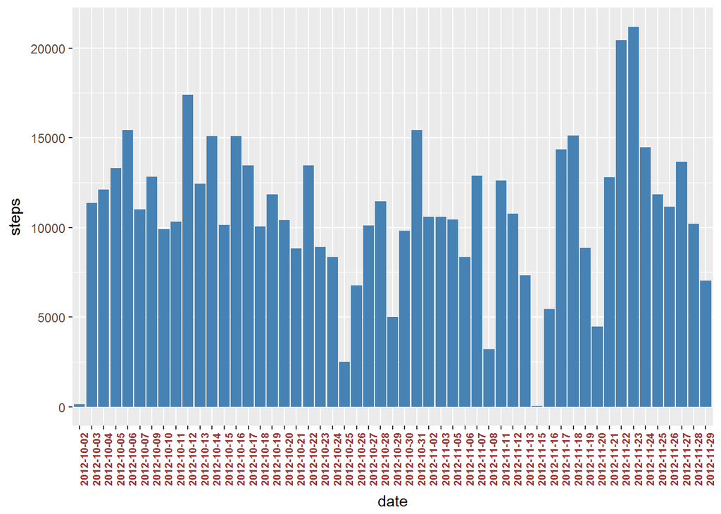

```r
nb.ByDate.steps<-aggregate(steps~date,data=activity.complete,sum)
ggplot(data=nb.ByDate.steps, aes(x=date, y=steps)) +geom_bar(stat="identity", fill="steelblue")+
        theme(axis.text.x = element_text(face="bold", color="#993333",  size=7, angle=90))
```

2. Histogram of the total number of steps taken each day :

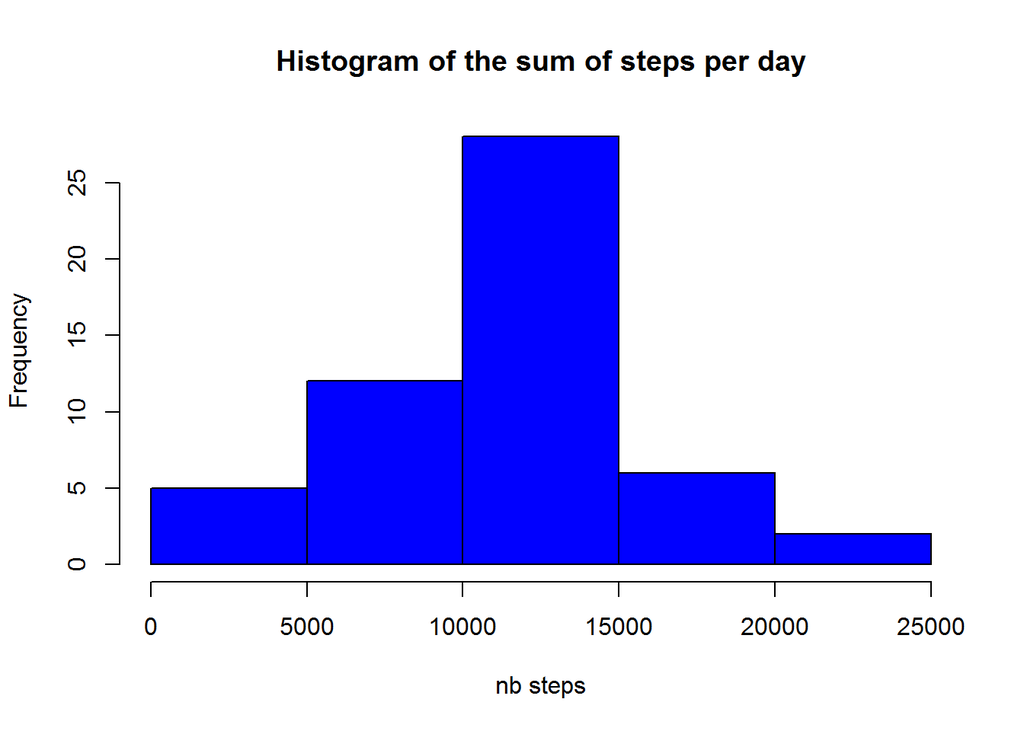

```r
hist(nb.ByDate.steps$steps,xlab="nb steps",main="Histogram of the sum of steps per day",col="blue")
```

3. Calculate and report the mean and median of the total number of steps taken per day :

```r
print(mean(nb.ByDate.steps$steps))
```

```
## [1] 10766.19
```

```r
print(median(nb.ByDate.steps$steps))
```

```
## [1] 10765
```

## What is the average daily activity pattern?

1. Make a time series plot (i.e. type = “l”) of the 5-minute interval (x-axis) and the average number of steps taken, averaged across all days (y-axis)

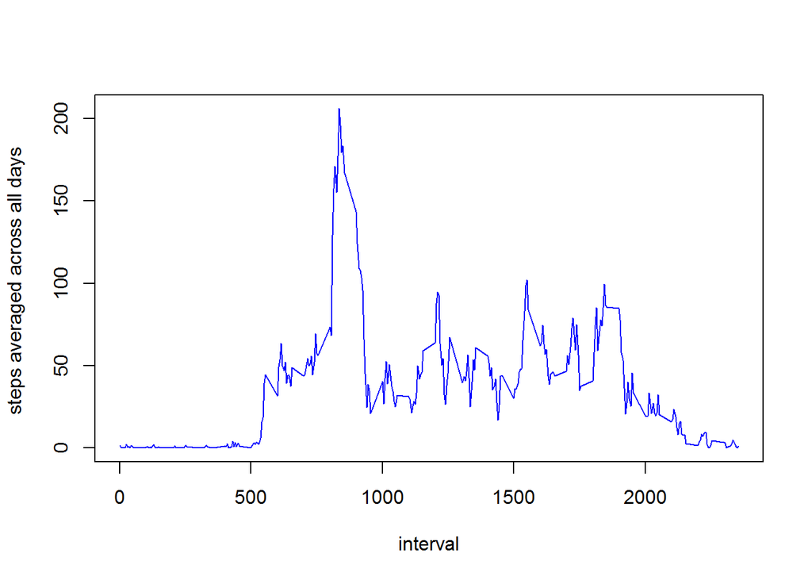

```r
meanByInterval.steps<-aggregate(steps~interval,data=activity.complete,mean)
with(meanByInterval.steps,plot(interval,steps,type="l",ylab="steps averaged across all days ",col="blue"))
```

2. Which 5-minute interval, on average across all the days in the dataset, contains the maximum number of steps?

```r
interval.max.steps<-meanByInterval.steps$interval[which.max(meanByInterval.steps$steps)]
```

The 5-minute interval which contains the maximum number of steps is 835.

## Imputing missing values

1. Calculate and report the total number of missing values in the dataset (i.e. the total number of rows with NAs)

```r
nrow.missing.value<-nrow(activity)-nrow(activity.complete)
```

The number of Nas is : 2304.

2. Devise a strategy for filling in all of the missing values in the dataset. The strategy does not need to be sophisticated. For example, you could use the mean/median for that day, or the mean for that 5-minute interval, etc.

In the following table, We can identify either days with only NA or days with complete data.

```r
table(activity[ok,2])
```

```
##
## 2012-10-01 2012-10-02 2012-10-03 2012-10-04 2012-10-05 2012-10-06
##          0        288        288        288        288        288
## 2012-10-07 2012-10-08 2012-10-09 2012-10-10 2012-10-11 2012-10-12
##        288          0        288        288        288        288
## 2012-10-13 2012-10-14 2012-10-15 2012-10-16 2012-10-17 2012-10-18
##        288        288        288        288        288        288
## 2012-10-19 2012-10-20 2012-10-21 2012-10-22 2012-10-23 2012-10-24
##        288        288        288        288        288        288
## 2012-10-25 2012-10-26 2012-10-27 2012-10-28 2012-10-29 2012-10-30
##        288        288        288        288        288        288
## 2012-10-31 2012-11-01 2012-11-02 2012-11-03 2012-11-04 2012-11-05
##        288          0        288        288          0        288
## 2012-11-06 2012-11-07 2012-11-08 2012-11-09 2012-11-10 2012-11-11
##        288        288        288          0          0        288
## 2012-11-12 2012-11-13 2012-11-14 2012-11-15 2012-11-16 2012-11-17
##        288        288          0        288        288        288
## 2012-11-18 2012-11-19 2012-11-20 2012-11-21 2012-11-22 2012-11-23
##        288        288        288        288        288        288
## 2012-11-24 2012-11-25 2012-11-26 2012-11-27 2012-11-28 2012-11-29
##        288        288        288        288        288        288
## 2012-11-30
##          0
```

So we we calculate the averaged values of steps for each 5-minutes interval (averaged accross all days). It gives a vector with 288 values which we will report in each day without steps value. The new dataset with imput data will be activity.imput.

3. Create a new dataset that is equal to the original dataset but with the missing data filled in.

```r
nb.NA.ByDate<-as.data.frame(table(activity$date[ok]))
colnames(nb.NA.ByDate)<-c("date","nb.NA")
nb.date<-nrow(nb.NA.ByDate)
activity.impute<-activity
for (i in 1:nb.date){
  if(nb.NA.ByDate[i,2] == 0){
    activity.impute[which(activity.impute$date==nb.NA.ByDate[i,1]),1]=meanByInterval.steps$steps
  }
}
```

4. Make a histogram of the total number of steps taken each day and Calculate and report the mean and median total number of steps taken per day.

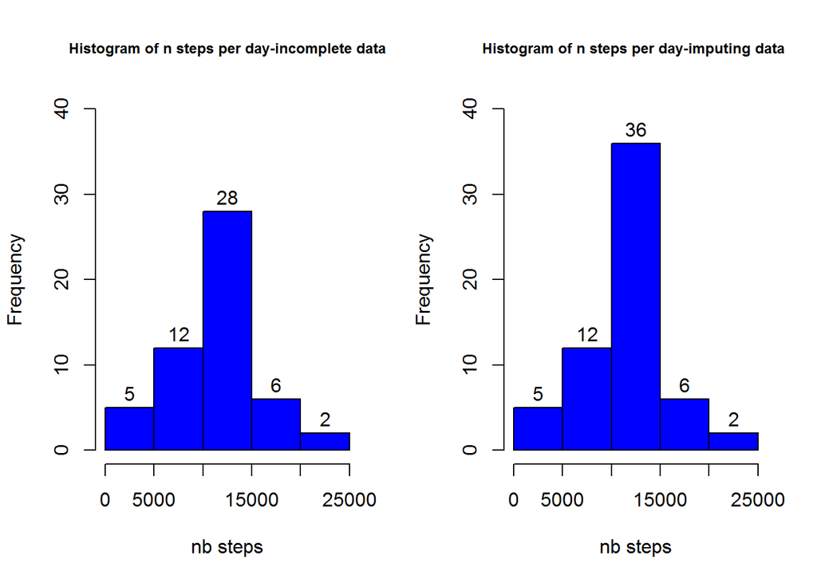

```r
nb.ByDate.steps.impute<-aggregate(steps~date,data=activity.impute,sum)
par(mfrow=c(1,2))
hist(nb.ByDate.steps$steps,xlab="nb steps",main="Histogram of n steps per day-incomplete data",ylim=c(0,40),cex.main=0.75,col="blue",labels=T)
hist(nb.ByDate.steps.impute$steps,xlab="nb steps",main="Histogram of n steps per day-imputing data ",ylim=c(0,40),cex.main=0.75,col="blue",labels=T)
```

```r
mean(nb.ByDate.steps$steps)
```

```
## [1] 10766.19
```

```r
mean(nb.ByDate.steps.impute$steps)
```

```
## [1] 10766.19
```

```r
median(nb.ByDate.steps$steps)
```

```
## [1] 10765
```

```r
median(nb.ByDate.steps.impute$steps)
```

```
## [1] 10766.19
```

We can notice that means are the same and the medians are very closed.

## Are there differences in activity patterns between weekdays and weekends?

1. Create a new factor variable in the dataset with two levels - “weekday” and “weekend” indicating whether a given date is a weekday or weekend day.

```r
activity.complete<-mutate(activity.complete,date=ymd(date))
activity.complete<-mutate(activity.complete,weekday="weekday")

activity.complete[which(weekdays(activity.complete$date) %in% c("samedi","dimanche")),4]<-"weekend"
activity.complete<-mutate(activity.complete,weekday=as.factor(weekday))
```

2. Make a panel plot containing a time series plot (i.e. type = “l”) of the 5-minute interval (x-axis) and the average number of steps taken, averaged across all weekday days or weekend days (y-axis)

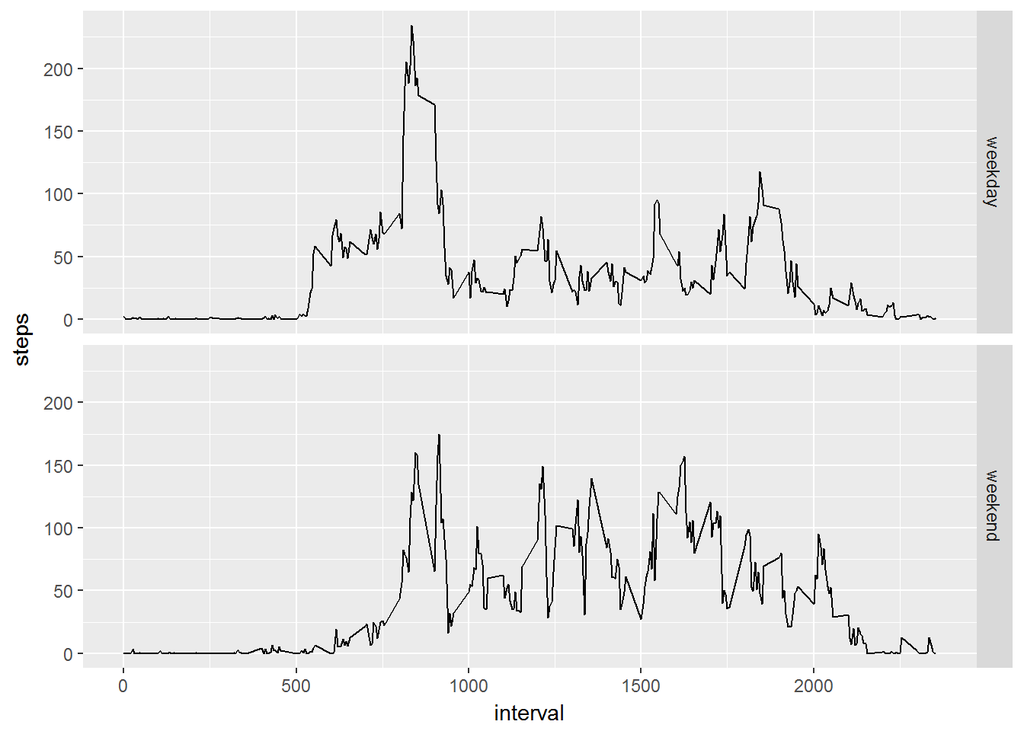

```r
nb.ByDate.steps<-aggregate(steps~interval+weekday,data=activity.complete,mean)
sp<-qplot(interval,steps,data=nb.ByDate.steps,geom="line")
sp + facet_grid(weekday ~ .)
```

```r
nb.ByDate.steps.filter<-mutate(nb.ByDate.steps,index=interval %in% 900:2000)
nb.ByDate.steps.filter<-filter(nb.ByDate.steps.filter,index == TRUE)

mean.day<-aggregate(steps~weekday,data=nb.ByDate.steps.filter,mean)
```

For week days, we notice an high level at 08:35, after the average steps level (5 min interval) is 45.1696549 during the day (09:00 - 20:00 period). In the week-end, the sum of steps is more spread during the day. The average level between 09:00 and 20:00 is 74.5725027 the week end.